# Vino: domande e risposte

## Presentazione del dataset analizzato

Il progetto analizza un dataset sul mondo del vino. Il dataset, dopo la rimozione di due campi non utili all’analisi, è così composto:

- X
- country
- descripition
- designation
- points
- price
- province
- region
- taster_name
- title
- variety
- winery

Il numero di entrate (righe) è 120’975

## Prezzo medio dei vini per paese I

Valutato in funzione dei vini più volte recensiti

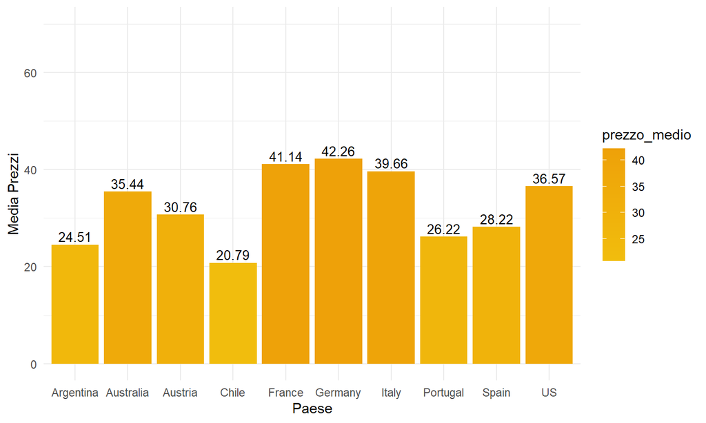

## Punteggio medio dei vini per paese I

Valutato in funzione dei vini più volte recensiti

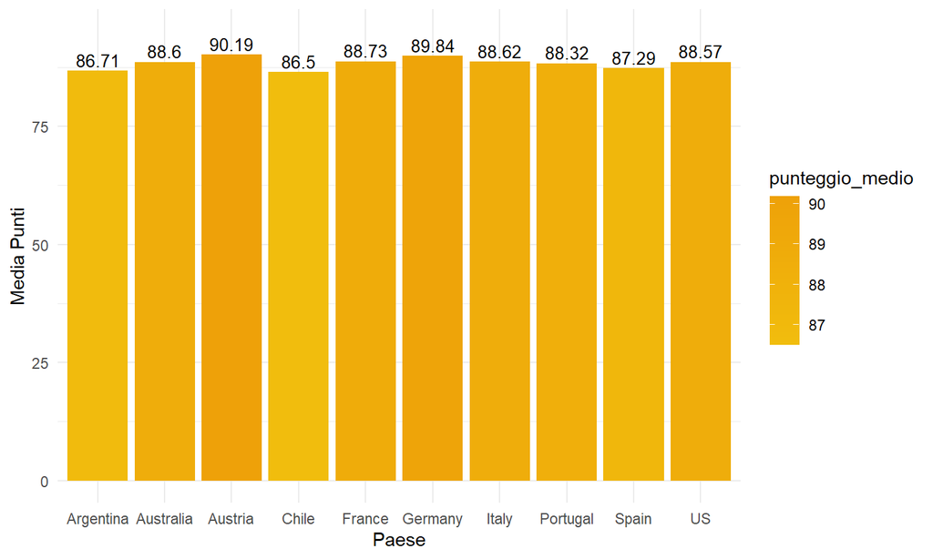

## Prezzo medio dei vini per paese II

Valutato esclusivamente sulla media

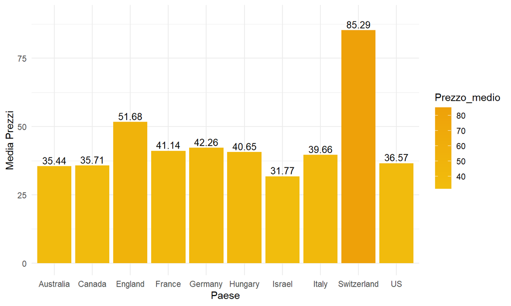

## Punteggio medio dei vini per paese II

Valutato esclusivamente sulla media

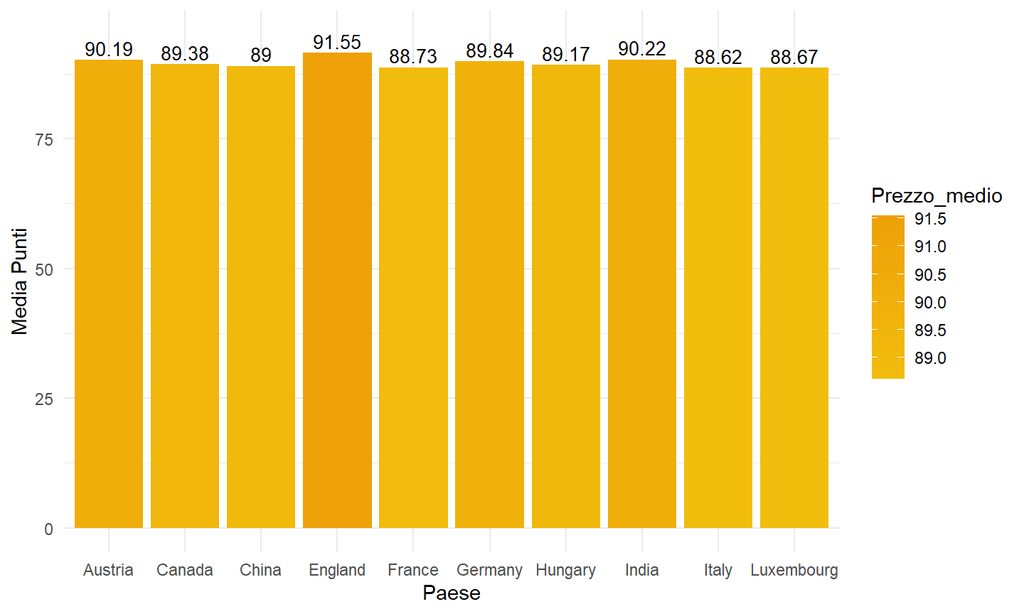

## Eccellenze nel mondo

*I vini suddivisi per paese che hanno preso il massimo del punteggio*

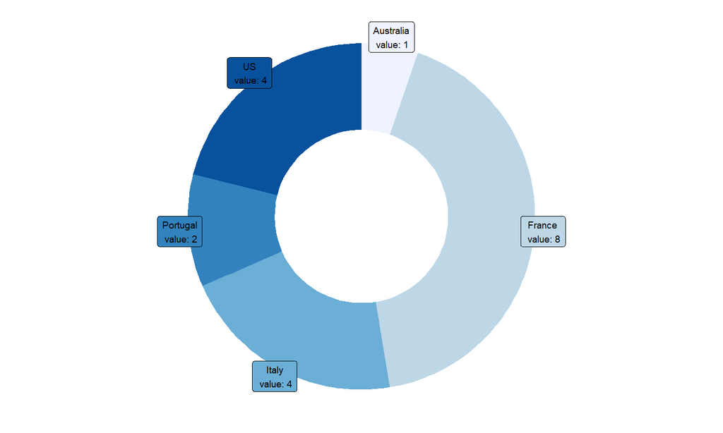

```
 [1] Chambers Rosewood Vineyards NV Rare Muscat (Rutherglen)
 [2] Avignonesi 1995 Occhio di Pernice  (Vin Santo di Montepulciano)
 [3] Krug 2002 Brut  (Champagne)
 [4] Tenuta dell'Ornellaia 2007 Masseto Merlot (Toscana)
 [5] Casa Ferreirinha 2008 Barca-Velha Red (Douro)
 [6] Biondi Santi 2010 Riserva  (Brunello di Montalcino)
 [7] Cardinale 2006 Cabernet Sauvignon (Napa Valley)
 [8] ChÃ¢teau LÃ©oville Barton 2010  Saint-Julien
 [9] Louis Roederer 2008 Cristal Vintage Brut  (Champagne)
[10] Salon 2006 Le Mesnil Blanc de Blancs Brut Chardonnay (Champagne)
[11] ChÃ¢teau Lafite Rothschild 2010  Pauillac
[12] Casanova di Neri 2007 Cerretalto  (Brunello di Montalcino)
[13] ChÃ¢teau Cheval Blanc 2010  Saint-Ã‰milion
[14] ChÃ¢teau LÃ©oville Las Cases 2010  Saint-Julien
[15] Charles Smith 2006 Royal City Syrah (Columbia Valley (WA))
[16] Quinta do Noval 2011 Nacional Vintage  (Port)
[17] VeritÃ© 2007 La Muse Red (Sonoma County)
[18] ChÃ¢teau Haut-Brion 2014  Pessac-LÃ©ognan
[19] Cayuse 2008 Bionic Frog Syrah (Walla Walla Valley (WA))
118840 Levels: :Nota Bene 2005 Una Notte Red (Washington) ...
```

## Varietà di uvaggi utilizzati

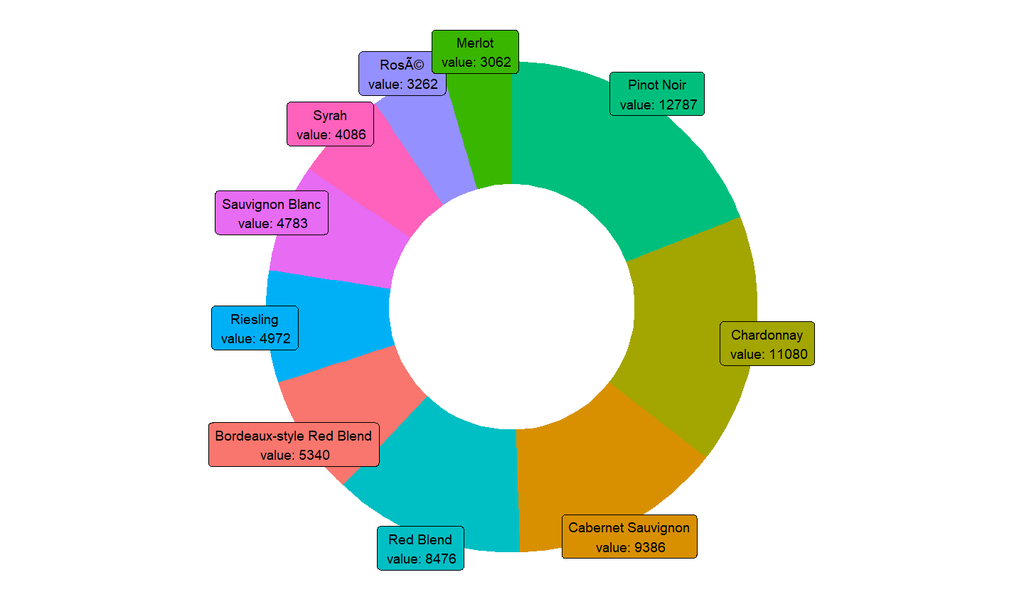

## La media dei voti assegnati dai giudici

I 5 giudici che hanno assegnato mediamente un punteggio più alto

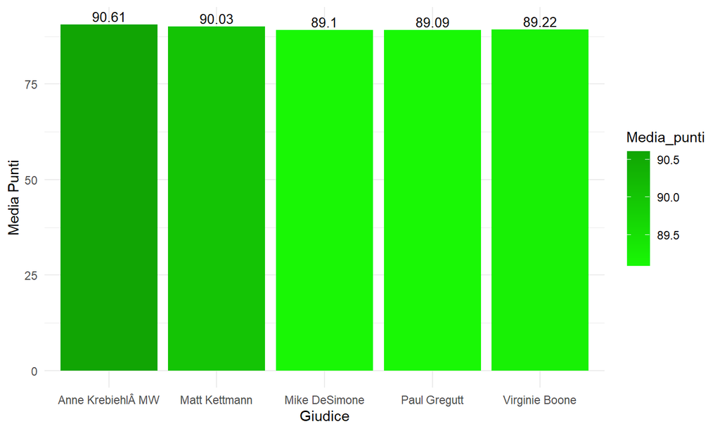

I 5 giudici che hanno assegnato mediamente un punteggio più basso

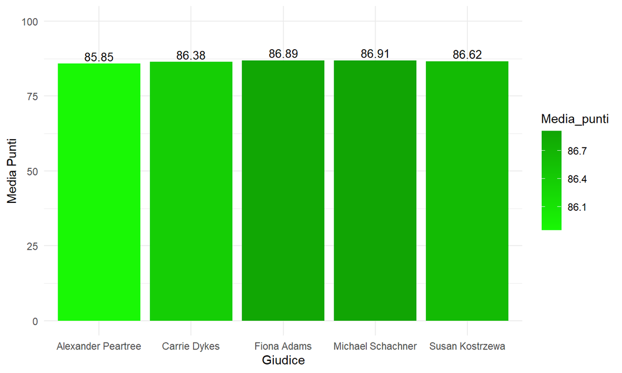

## Vini e annate

Le annate piu volte recensite

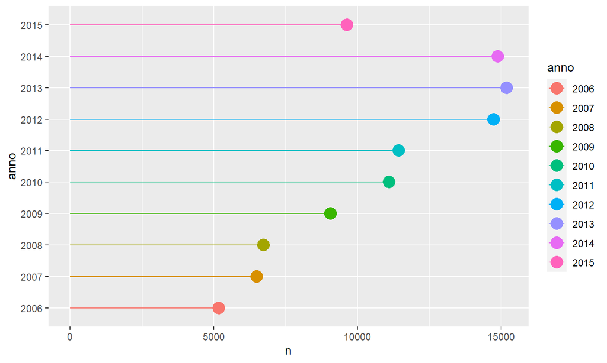

## Eccellenze italiane

I primi 10 vini italiani per punteggio assegnatogli

```
                                                                title points
1     Avignonesi 1995 Occhio di Pernice  (Vin Santo di Montepulciano)    100
2                 Tenuta dell'Ornellaia 2007 Masseto Merlot (Toscana)    100
3                 Biondi Santi 2010 Riserva  (Brunello di Montalcino)    100
4          Casanova di Neri 2007 Cerretalto  (Brunello di Montalcino)    100
5               Tenuta San Guido 2012 Sassicaia  (Bolgheri Sassicaia)     99
6                         Le Macchiole 2007 Messorio Merlot (Toscana)     99
7  Mascarello Giuseppe e Figlio 2008 CÃ  d'Morissio Riserva  (Barolo)     99
8              Mascarello Giuseppe e Figlio 2010 Monprivato  (Barolo)     99
9                           Gaja 2007 SorÃ¬ TildÃ¬n Nebbiolo (Langhe)     99
10                      Gaja 2007 SorÃ¬ San Lorenzo Nebbiolo (Langhe)     99
```

## Champagne VS Prosecco I

*La media dei punteggi ottenuta dallo Champagne*

```
[1] 90.26
```

*La media dei punteggi ottenuta dal Prosecco*

```
[1] 86.96
```

*La media dei prezzi ottenuta dallo Champagne*

```
[1] 79.46
```

*La media dei prezzi ottenuta dal Prosecco*

```
[1] 19.45
```

*Confronto grafico*

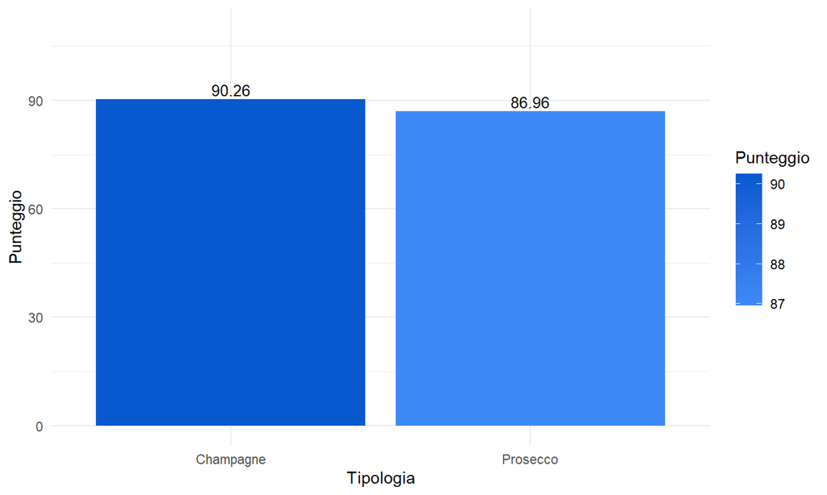

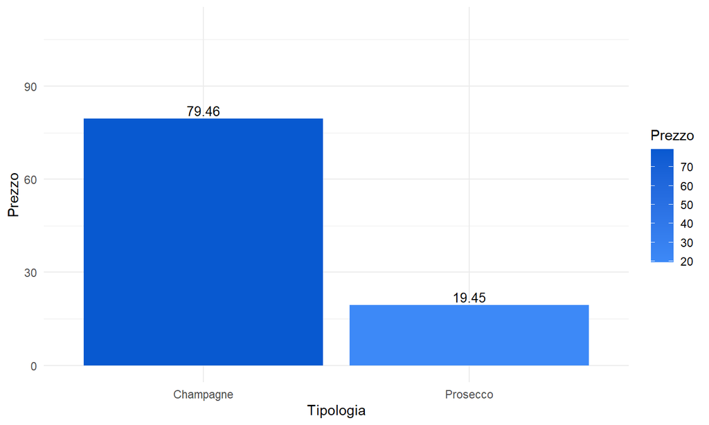

## Champagne VS Prosecco II

*Traguardi raggiunti*

Solo lo Champagne riesce ad aggiudicarsi punteggi così importanti (98+)

```
                                                                 title points
1                                          Krug 2002 Brut  (Champagne)    100
2                Louis Roederer 2008 Cristal Vintage Brut  (Champagne)    100
3     Salon 2006 Le Mesnil Blanc de Blancs Brut Chardonnay (Champagne)    100
4 Krug 2002 Clos du Mesnil Brut Blanc de Blancs Chardonnay (Champagne)     99
5     Salon 2004 Le Mesnil Blanc de Blancs Brut Chardonnay (Champagne)     98
6        Pol Roger 2002 CuvÃ©e Sir Winston Churchill Brut  (Champagne)     98
```

## Fine presentazione

*Considerazioni*

Quello che ho riscontrato durante l’analisi del mio dataset è stato spesso coerente con il mio sapere frutto della passione per il vino. Altri risultati hanno dato risultati inaspettati o per lo meno sono stati meno interessanti di altri. E di conseguenza anche meno contestualizzabili.

Enrico Martin